# Gun Data: Was there an increase in permits during the 2016 Presidential Election?

- Introduction
- Data Wrangling
- Exploratory Data Analysis
- Conclusions

## Introduction

> The Gun Data from the FBI's NICS (National Instant Criminal Background Check System) shows the gun permit checks from November 1998 to present. The data is broken into monthly reports and is available online through the FBI's website, FBI.gov. The data does not represent gun purchases but rather background checks. As the FBI's site advises, there is not a one to one correlation between checks and gun purchases. Each column in the data show different types of checks that occurr.

> The question that I would like to answer is whether or not gun checks increase in the run up to the 2016 US Presidential Election. I will further break this down to see if the increases happen on party lines by showing the differences in permit checks between Red (Republican) and Blue (Democrat) States.

```python
# Import Pandas, numpy, matplotlib and seaborn.
import pandas as pd
import numpy as np
import matplotlib.pyplot as plt
import seaborn as sns
% matplotlib inline
```

## Data Wrangling

> The data that we are using runs from the NICS inception, November 1998, until September 2017. Below the data is loaded and we begin our trek to learn about what is in this report. In loading the data, the Month column is parsed into dates.

### General Properties

```python
#Import Gun Data and parse dates
df = pd.read_csv('gun_data.csv', parse_dates=[0])
```

> The first step will be to check the data. I want to get a brief overview of the data types, shape and null values.

```python
#Check the first 5 lines of the data set using .head
df.head()
```

|  | month | state | permit | permit_recheck | handgun | long_gun | other | multiple | admin | prepawn_handgun | ... | returned_other | rentals_handgun | rentals_long_gun | private_sale_handgun | private_sale_long_gun | private_sale_other | return_to_seller_handgun | return_to_seller_long_gun | return_to_seller_other | totals |
| --- | --- | --- | --- | --- | --- | --- | --- | --- | --- | --- | --- | --- | --- | --- | --- | --- | --- | --- | --- | --- | --- |
| 0 | 2017-09-01 | Alabama | 16717.0 | 0.0 | 5734.0 | 6320.0 | 221.0 | 317 | 0.0 | 15.0 | ... | 0.0 | 0.0 | 0.0 | 9.0 | 16.0 | 3.0 | 0.0 | 0.0 | 3.0 | 32019 |
| 1 | 2017-09-01 | Alaska | 209.0 | 2.0 | 2320.0 | 2930.0 | 219.0 | 160 | 0.0 | 5.0 | ... | 0.0 | 0.0 | 0.0 | 17.0 | 24.0 | 1.0 | 0.0 | 0.0 | 0.0 | 6303 |
| 2 | 2017-09-01 | Arizona | 5069.0 | 382.0 | 11063.0 | 7946.0 | 920.0 | 631 | 0.0 | 13.0 | ... | 0.0 | 0.0 | 0.0 | 38.0 | 12.0 | 2.0 | 0.0 | 0.0 | 0.0 | 28394 |
| 3 | 2017-09-01 | Arkansas | 2935.0 | 632.0 | 4347.0 | 6063.0 | 165.0 | 366 | 51.0 | 12.0 | ... | 0.0 | 0.0 | 0.0 | 13.0 | 23.0 | 0.0 | 0.0 | 2.0 | 1.0 | 17747 |
| 4 | 2017-09-01 | California | 57839.0 | 0.0 | 37165.0 | 24581.0 | 2984.0 | 0 | 0.0 | 0.0 | ... | 0.0 | 0.0 | 0.0 | 0.0 | 0.0 | 0.0 | 0.0 | 0.0 | 0.0 | 123506 |

5 rows × 27 columns

```python
#Check the last 5 rows to see what it looks like
df.tail()
```

|  | month | state | permit | permit_recheck | handgun | long_gun | other | multiple | admin | prepawn_handgun | ... | returned_other | rentals_handgun | rentals_long_gun | private_sale_handgun | private_sale_long_gun | private_sale_other | return_to_seller_handgun | return_to_seller_long_gun | return_to_seller_other | totals |
| --- | --- | --- | --- | --- | --- | --- | --- | --- | --- | --- | --- | --- | --- | --- | --- | --- | --- | --- | --- | --- | --- |
| 12480 | 1998-11-01 | Virginia | 0.0 | NaN | 14.0 | 2.0 | NaN | 8 | 0.0 | NaN | ... | NaN | NaN | NaN | NaN | NaN | NaN | NaN | NaN | NaN | 24 |
| 12481 | 1998-11-01 | Washington | 1.0 | NaN | 65.0 | 286.0 | NaN | 8 | 1.0 | NaN | ... | NaN | NaN | NaN | NaN | NaN | NaN | NaN | NaN | NaN | 361 |
| 12482 | 1998-11-01 | West Virginia | 3.0 | NaN | 149.0 | 251.0 | NaN | 5 | 0.0 | NaN | ... | NaN | NaN | NaN | NaN | NaN | NaN | NaN | NaN | NaN | 408 |
| 12483 | 1998-11-01 | Wisconsin | 0.0 | NaN | 25.0 | 214.0 | NaN | 2 | 0.0 | NaN | ... | NaN | NaN | NaN | NaN | NaN | NaN | NaN | NaN | NaN | 241 |
| 12484 | 1998-11-01 | Wyoming | 8.0 | NaN | 45.0 | 49.0 | NaN | 5 | 0.0 | NaN | ... | NaN | NaN | NaN | NaN | NaN | NaN | NaN | NaN | NaN | 107 |

5 rows × 27 columns

```python
#Check for data types by column, amount of non-null values per column
df.info()
```

```
<class 'pandas.core.frame.DataFrame'>
RangeIndex: 12485 entries, 0 to 12484
Data columns (total 27 columns):
month                        12485 non-null datetime64[ns]
state                        12485 non-null object
permit                       12461 non-null float64
permit_recheck               1100 non-null float64
handgun                      12465 non-null float64
long_gun                     12466 non-null float64
other                        5500 non-null float64
multiple                     12485 non-null int64
admin                        12462 non-null float64
prepawn_handgun              10542 non-null float64
prepawn_long_gun             10540 non-null float64
prepawn_other                5115 non-null float64
redemption_handgun           10545 non-null float64
redemption_long_gun          10544 non-null float64
redemption_other             5115 non-null float64
returned_handgun             2200 non-null float64
returned_long_gun            2145 non-null float64
returned_other               1815 non-null float64
rentals_handgun              990 non-null float64
rentals_long_gun             825 non-null float64
private_sale_handgun         2750 non-null float64
private_sale_long_gun        2750 non-null float64
private_sale_other           2750 non-null float64
return_to_seller_handgun     2475 non-null float64
return_to_seller_long_gun    2750 non-null float64
return_to_seller_other       2255 non-null float64
totals                       12485 non-null int64
dtypes: datetime64[ns](1), float64(23), int64(2), object(1)
memory usage: 2.6+ MB
```

```python
#Check the shape of the data
df.shape
```

```
(12485, 27)
```

```python
#Check the mean, standard deviation and quartiles of the data to give a good picture of where the data is spread.
df.describe()
```

|  | permit | permit_recheck | handgun | long_gun | other | multiple | admin | prepawn_handgun | prepawn_long_gun | prepawn_other | ... | returned_other | rentals_handgun | rentals_long_gun | private_sale_handgun | private_sale_long_gun | private_sale_other | return_to_seller_handgun | return_to_seller_long_gun | return_to_seller_other | totals |
| --- | --- | --- | --- | --- | --- | --- | --- | --- | --- | --- | --- | --- | --- | --- | --- | --- | --- | --- | --- | --- | --- |
| count | 12461.000000 | 1100.000000 | 12465.000000 | 12466.000000 | 5500.000000 | 12485.000000 | 12462.000000 | 10542.000000 | 10540.000000 | 5115.000000 | ... | 1815.000000 | 990.000000 | 825.000000 | 2750.000000 | 2750.000000 | 2750.000000 | 2475.000000 | 2750.000000 | 2255.000000 | 12485.000000 |
| mean | 6413.629404 | 1165.956364 | 5940.881107 | 7810.847585 | 360.471636 | 268.603364 | 58.898090 | 4.828021 | 7.834156 | 0.165591 | ... | 1.027548 | 0.076768 | 0.087273 | 14.936000 | 11.602909 | 1.030182 | 0.402020 | 0.441818 | 0.105987 | 21595.725911 |
| std | 23752.338269 | 9224.200609 | 8618.584060 | 9309.846140 | 1349.478273 | 783.185073 | 604.814818 | 10.907756 | 16.468028 | 1.057105 | ... | 4.386296 | 0.634503 | 0.671649 | 71.216021 | 54.253090 | 4.467843 | 1.446568 | 1.528223 | 0.427363 | 32591.418387 |
| min | 0.000000 | 0.000000 | 0.000000 | 0.000000 | 0.000000 | 0.000000 | 0.000000 | 0.000000 | 0.000000 | 0.000000 | ... | 0.000000 | 0.000000 | 0.000000 | 0.000000 | 0.000000 | 0.000000 | 0.000000 | 0.000000 | 0.000000 | 0.000000 |
| 25% | 0.000000 | 0.000000 | 865.000000 | 2078.250000 | 17.000000 | 15.000000 | 0.000000 | 0.000000 | 0.000000 | 0.000000 | ... | 0.000000 | 0.000000 | 0.000000 | 0.000000 | 0.000000 | 0.000000 | 0.000000 | 0.000000 | 0.000000 | 4638.000000 |
| 50% | 518.000000 | 0.000000 | 3059.000000 | 5122.000000 | 121.000000 | 125.000000 | 0.000000 | 0.000000 | 1.000000 | 0.000000 | ... | 0.000000 | 0.000000 | 0.000000 | 0.000000 | 0.000000 | 0.000000 | 0.000000 | 0.000000 | 0.000000 | 12399.000000 |
| 75% | 4272.000000 | 0.000000 | 7280.000000 | 10380.750000 | 354.000000 | 301.000000 | 0.000000 | 5.000000 | 8.000000 | 0.000000 | ... | 0.000000 | 0.000000 | 0.000000 | 2.000000 | 4.000000 | 0.000000 | 0.000000 | 0.000000 | 0.000000 | 25453.000000 |
| max | 522188.000000 | 116681.000000 | 107224.000000 | 108058.000000 | 77929.000000 | 38907.000000 | 28083.000000 | 164.000000 | 269.000000 | 49.000000 | ... | 64.000000 | 12.000000 | 12.000000 | 1017.000000 | 777.000000 | 71.000000 | 28.000000 | 17.000000 | 4.000000 | 541978.000000 |

8 rows × 25 columns

```python
#Check for the unique values in each column.
#Looking at the State and Month columns it appears that each state is represented with each month
df.nunique()
```

```
month                          227
state                           55
permit                        5390
permit_recheck                 168
handgun                       7381
long_gun                      8350
other                         1226
multiple                      1387
admin                          499
prepawn_handgun                 90
prepawn_long_gun               133
prepawn_other                   16
redemption_handgun            1893
redemption_long_gun           2370
redemption_other                47
returned_handgun               237
returned_long_gun              113
returned_other                  34
rentals_handgun                  9
rentals_long_gun                 8
private_sale_handgun           152
private_sale_long_gun          136
private_sale_other              43
return_to_seller_handgun        17
return_to_seller_long_gun       17
return_to_seller_other           5
totals                       10218
dtype: int64
```

> Looking at the Month & the State columns one can see that eat month profiles each state. For each month there will be 55 entries, 50 states plus the US Territories. There are 12485 rows and 227 months x 55 States = 12485. In reading the information on the FBI's website there are different laws in different states on gun permitting. The most wholistic way to look at how many checks occurred will be to look at the "totals" column.

### Data Cleaning: What needs to go?

> In looking through the different columns and after checking the duplicates and null values we will replace null values with 0. I will create masks for my analysis for state, month and totals in order to get the answers I need. As I said previously, the FBI's description for the totals column makes it the most accurate for measuring the number of permits per state per month. Per the FBI website, they explain that each state has different rubics for checking gun permits. So the largest basket to catch all background checks will be the totals column.

> I did not need much cleaning done, however, I will organize and mask certain protions of the data to work through in my analysis below. The question I would like to answer is whether or not gun checks increase during presidential election cycles. I will order the dates as 10 months prior to the election and 10 months post election in order to see if there are any significant changes in checks. The 5 US territories cannot vote in the election and so I will take those out of the data.

```python
#I want to fill null values with a 0.  The totals column is counting null values as 0 anyway.
df.fillna(0)
```

[output not shown]

12485 rows × 27 columns

## Gun Checks leading up to the 2016 Presidential Election

> The first step will be to break down the data into the State, Month and total permits for each. Then I will show the total permits

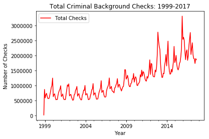

```python
#The below graph sohws the total number of background checks from the inception of NICS.
#I grouped by month and summed the totals to see the total checks country wide by month.
df.groupby('month').sum().totals.plot(kind='line', color = 'red', label='Total Checks')
plt.xlabel('Year')
plt.ylabel('Number of Checks')
plt.legend()
plt.title('Total Criminal Background Checks: 1999-2017');
```

> In looking at the above charts which shows the total amount of firearm background checks between 1999 and 2017 there are several things that stand out. As you can see there is a significant increase around the year 2012 and then again between 2015 and 2016.

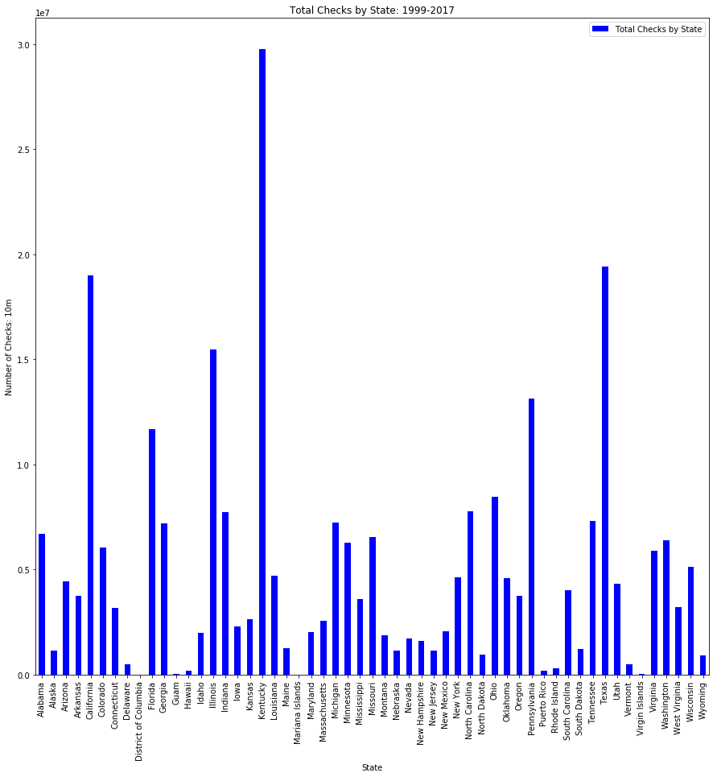

```python
#Plot the Totals by State over the 18 year period of the NICS
df.groupby('state').sum().totals.plot(kind='bar', figsize=(15,15), color ='blue', label='Total Checks by State')
plt.xlabel('State')
plt.ylabel('Number of Checks: 10m')
plt.legend()
plt.title('Total Checks by State: 1999-2017');
```

> In looking at the State bar chart there are two questions I need to check on. 1) Are there outliers in Kentucky that will cause problems in our data set. 2) It appears that historically Republican or "Red States" have higher totals than Democrat or "Blue States". The other states with higher than normal checks are California, Texas, Illinois, and Pennsylvania. California, Florida and Texas have three of the largest populations in the nation and that could be the reason for higher than normal checks. Illinois has very stringent firearm laws and could be the reason for their high count as well. As I state in the conclusion, States have different laws on background checks and could be a reason for the difference in checks.

> I would like to see if the 10 months before and after the US Presidential Election cycles of 2012 and 2016 if these checks occurred more often. I want to answer if Red States, which I define by the 2016 election results via the New York Times (https://www.nytimes.com/elections/results/president), had a higher rate of background checks than Blue States. Red States are those that voted for Donald Trump and Blue States are those that went for Hilary Clinton.

```python
#Query only Rows that contain Kentucky
df_kent = df.query('state =="Kentucky"')
```

```python
#Look at the mean, standard variation and quartiles of Kentucky's totals
df_kent.totals.describe()
```

```
count       227.000000
mean     131112.044053
std      113947.575479
min         840.000000
25%       20065.000000
50%      128745.000000
75%      211062.500000
max      398706.000000
Name: totals, dtype: float64
```

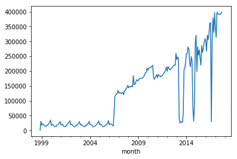

```python
#Chart Kentucky's Checks by month over the 18 year period to see if there are outliers
df_kent.groupby('month').sum().totals.plot(kind='line');
```

### Blue State vs Red State

```python
#Change break down the states into Red State and Blue State based on 2016 election results.
df_redstate = df.query('state == ["Tennessee", "Georgia", "Arizona", "Utah", "Alaska", "Texas", "Oklahoma", "Louisiana", "Arkansas", "North Dakota","South Dakota", "Indiana", "Montana", "Wyoming", "Nebraska", "Kansas", "Missouri", "Iowa", "Wisconsin", "Mississippi", "Michigan", "Kentucky", "Alabama", "Florida", "South Carolina", "North Carolina", "West Virginia", "Ohio", "Pennsylvania"]')
df_bluestate = df.query('state == ["Washington", "Oregon", "California", "Nevada", "Colorado", "New Mexico", "Illinois", "Minnesota", "Virginia", "New York", "Vermont", "New Hampshire", "Massachusetts", "Conneticut", "Maine", "New Jersey", "Maryland", "Hawaii"]')
```

Setting Up the 2016 Election: Below masks are set up for the Red and Blue states in pre and post 10 month periods around the elections of 2016 and 2012.

```python
#Breakdown the Red and Blue States into different time frames, Pre-2016 Election, Post 2016 Election,
# Pre-2012 Election and Post 2012 Election.  These are 10 month time periods.
df_redstate_ptele = df_redstate.query('month > "2016-11"')
df_bluestate_ptele = df_bluestate.query('month > "2016-11"')
df_bluestate_prele = df_bluestate[df_bluestate.month.between('2016-02', '2016-11')]
df_redstate_prele = df_redstate[df_redstate.month.between('2016-02', '2016-11')]
df_rs_ptele_12 = df_redstate[df_redstate.month.between('2012-12', '2013-09')]
df_rs_prele_12 = df_redstate[df_redstate.month.between('2012-02', '2012-11')]
df_bs_ptele_12 = df_bluestate[df_bluestate.month.between('2012-12', '2013-09')]
df_bs_prele_12 = df_bluestate[df_bluestate.month.between('2012-02', '2012-11')]
```

Below are two line charts of the Blue and Red States for 1) Pre-2016 Election and 2) Post 2016 Election.

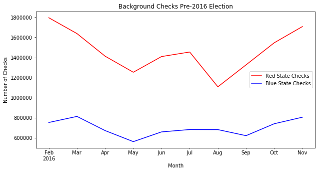

```python
#Graph Pre-2016 Background Checks summing totals by month
df_redstate_prele.groupby('month').sum().totals.plot(kind='line', color = 'red', label='Red State Checks')
df_bluestate_prele.groupby('month').sum().totals.plot(kind='line', color = 'blue', figsize=(10,5), label='Blue State Checks')
plt.xlabel('Month')
plt.ylabel('Number of Checks')
plt.legend()
plt.title('Background Checks Pre-2016 Election');
```

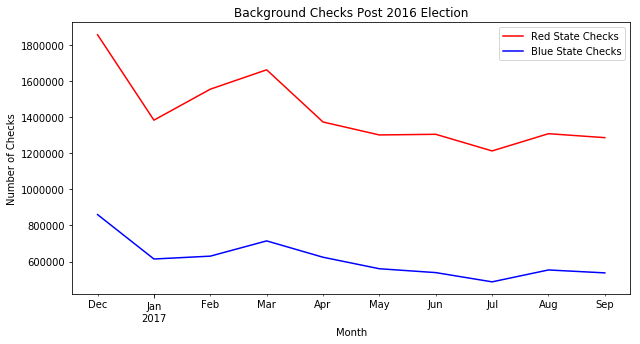

```python
#Graph Post 2016 Election Background Checks by total checks per month
df_redstate_ptele.groupby('month').sum().totals.plot(kind='line', color = 'red', label='Red State Checks')
df_bluestate_ptele.groupby('month').sum().totals.plot(kind='line', color = 'blue', figsize=(10,5), label='Blue State Checks')
plt.xlabel('Month')
plt.ylabel('Number of Checks')
plt.legend()
plt.title('Background Checks Post 2016 Election');
```

The next two charts show the number of background checks Pre and Post 2012 Election

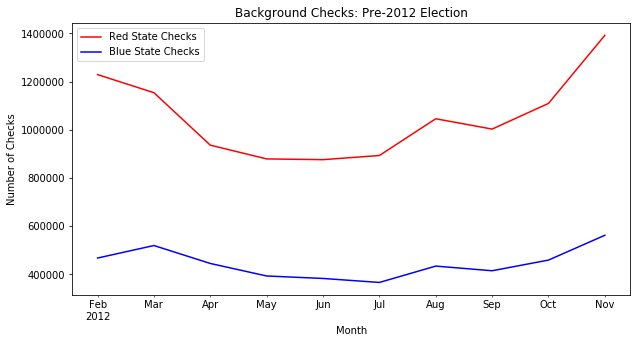

```python
#Graph Pre-2012 Election Background Check totals
df_rs_prele_12.groupby('month').sum().totals.plot(kind='line', color = 'red', label='Red State Checks')
df_bs_prele_12.groupby('month').sum().totals.plot(kind='line', color = 'blue', figsize=(10,5), label='Blue State Checks')
plt.xlabel('Month')
plt.ylabel('Number of Checks')
plt.legend()
plt.title('Background Checks: Pre-2012 Election');
```

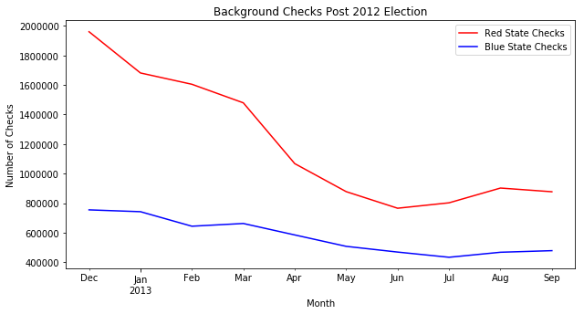

```python
#Graph Post 2012 Election background check totals by month
df_rs_ptele_12.groupby('month').sum().totals.plot(kind='line', color = 'red', label='Red State Checks')
df_bs_ptele_12.groupby('month').sum().totals.plot(kind='line', color = 'blue', figsize=(10,5), label='Blue State Checks')
plt.xlabel('Month')
plt.ylabel('Number of Checks')
plt.legend()
plt.title('Background Checks Post 2012 Election');
```

```python
#Group Red and Blue States into a time period from February 2012, 10 months prior to 2012 election, to the present
df_rs_2012_16 = df_redstate.query('month > "2012-02"')
df_bs_2012_16 = df_bluestate.query('month > "2012-02"')
```

```python
#Check the sum total of Red State checks for the above period
df_rs_2012_16.sum().totals
```

```
85928763.0
```

```python
#Check the sum total of Blue State checks for the above period
df_bs_2012_16.sum().totals
```

```
37851662.0
```

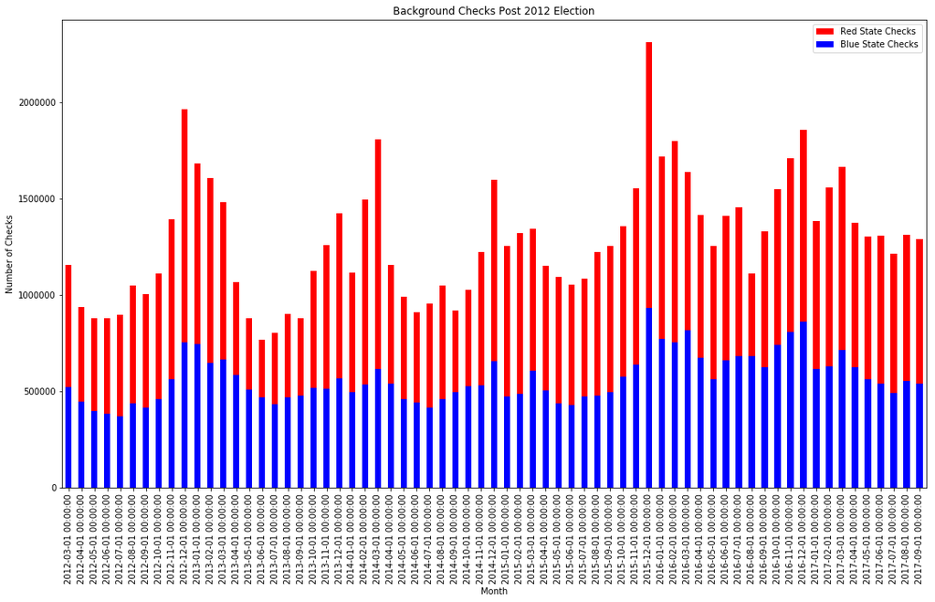

```python
#Graph totals of Blue and Red States for that time period in a stacked bar chart
df_rs_2012_16.groupby('month').sum().totals.plot(kind='bar', color = 'red', label='Red State Checks')
df_bs_2012_16.groupby('month').sum().totals.plot(kind='bar', color = 'blue', figsize=(18,10), label='Blue State Checks')
plt.xlabel('Month')
plt.ylabel('Number of Checks')
plt.legend()
plt.title('Background Checks Post 2012 Election');
```

## Conclusions

> While in both 2012 and 2016 there are increases in background checks through the NICS, there is not a direct correlation between it being a run up to the election and the increase in checks. When one looks at the line chart showing the totals over the almost 20 year period of the NICS, every year there is an increase toward the end of the year and the a drop off at the beginning of the next year. There could be many reasons for this increase: retailers do better toward the end of the year and Christmas. "Black Friday" sales in November could be a reason for increases as could Christmas sales. There is not enough information to make a definate statement that political elections cause massive increases in background checks.

> The data is incomplete by the FBI's own recollection. As this database started in the 1990's there were growing pains and therefore not all checks could have been recorded. Background checks do not mean a gun was purchased and furthermore more than one gun can be purchased per check so there is not a correlation of gun purchases to checks. Also, as we look at state to state numbers, a citizen of one state can drive into another state and get checked for a purchase or permit.